# Network Analysis for Ecologists (NWAE01)

Miguel Lurgi

2025-10-30

# 1 Methods for network analysis

## 1.1 What is a network?

A network (or graph in mathematics) is a set of elements with specific characteristic relationships between them. We call the elements vertices (or nodes) and the relations between them edges (or links). In the picture below we can see a network composed of 8 nodes and 10 links between them.

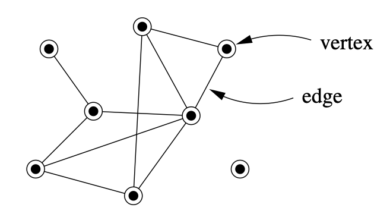

There are a couple of things to be noted about this network, which we will revisit later on. The links between the nodes do not have an apparent directionality, making this an **undirected graph**. On the other hand, when the direction between link is relevant, such as for example in a predator-prey interaction, where it is convenient to represent the fact that the flow of biomass runs from prey to predator, the links might be represented as arrows. Networks represented in this way are called **directed graphs**.

Secondly, one of the nodes is *isolated*. Can you guess which one it is?

You might have started noticing that depending on the types of links, and their placement between nodes within the network, there are a few categories under which we can classify networks according to their features. Two categories are relevant for this course:

1.- Networks can be either **directed** or **undirected** as we saw before.

2.- Depending on the constraints of connectivity between groups of nodes, networks can be classified as either **unipartite** where all nodes could in principle be connected to any other node, or **bipartite**, where two different groups of nodes exist in which *links between nodes in different groups occur* but links between nodes *within the same group do not*.

We will encounter both **unipartite** and **bipartite** networks along the way. Watch out!

Many systems both natural and man-made, can be thought of as networks. From the network of airports around to world and the air routes connecting them, to the World Wide Web and the links between web pages, or social networks of friendships (both real and digital), all the way down to microscopic entities such as gene and metabolic networks, these systems can be represented and, perhaps more importantly, analysed as networks.

[figure not shown]

The field of mathematics has been studying networks for decades. The mathematics subfield of [Graph Theory](https://en.wikipedia.org/wiki/Graph_theory) has developed extensive frameworks to analyse and manipulate mathematical objects known as `graphs`. Graphs, as networks, are simply collections of nodes and links between them. So, we can represent networks as graphs and take advantage of the mathematical framework of Graph Theory to study them.

[figure not shown]

The mathematical study of graphs (or networks) arguably started in 1735 when the celebrated mathematician [Leonhard Euler](https://en.wikipedia.org/wiki/Leonhard_Euler), yes!, the same one who introduced the *e* as the base of the natural logarithm, developed what is considered the first theorem of graph theory to solve the problem known as the [Seven bridges of Königsberg](https://en.wikipedia.org/wiki/Seven_Bridges_of_K%C3%B6nigsberg).

Ever since then, the application of graph theory has percolated the sciences. It started back in the 1930s when tools for the analysis of networks were applied to the social sciences to develop a better understanding of social relationships among humans.

In ecology, even though network representations of natural communities can be traced back to the 1880’s in the work by [Lorenzo Camerano](https://en.wikipedia.org/wiki/Lorenzo_Camerano), the quantitative analysis of networks and their properties, as well as their mathematical modelling, started much more recently, around the 1960’s - 70’s.

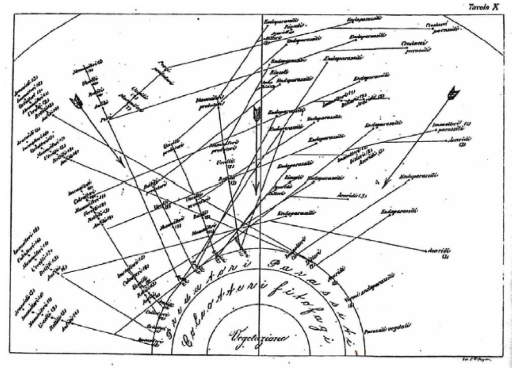

**Lorenzo Camerano’s representation of a food web (1880)**

In the following sections we will learn how to analyse networks. Our focus will be networks of ecological interactions between species sharing the same ecological community. In very diverse systems these can be up to 1,000’s of species. As such, many of the quantities we will be learning about are mostly relevant to quantify **biodiversity** and can be seen as a natural extension to the classical analysis performed in **community ecology**. Nonetheless, the underlying principles of network construction and analysis can be applied to any networked system, including those mentioned above.

## 1.2 Network formats: edgelists and adjacency matrices

To be able to manipulate and analyse networks in an automated way, we need to represent them in a way that is understandable by a computer. Several computer readable formats exist to store the description and information contained in a network. The most commonly used in ecology (and other disciplines) are: (i) adjacency matrices, and (ii) edgelists.

**Adjancecy matrices**, one of the most common ways of representing networks in mathematics, are matrices in which columns and rows represent the nodes (species) in the network, and a link (interaction) between them is represented as a 1, while the absence of a link is represented as a 0.

In a foodweb, for example, as we saw previously, links are directed from prey to predator. In the adjacency matrix, the rows represent prey species and the columns represent predators. Thus, an interaction a<sub>ij</sub> runs from prey i to predator j.

**Adjacency matrices** are good for representing **unipartite** networks because in principle there could be a connection between any two nodes. In **bipartite** networks on the other hand, as we saw before, we know in advance that some links cannot occur (i.e. those between nodes within the same groups). As such all nodes do not have to be represented in each dimension of the matrix (rows and columns) but only in one of them. This gives rise to a slightly different format from an adjacency matrix, but where the meaning of the elements in the matrix is still the same. These are **incidence matrices**. In and **incidence matrix** one set of nodes is represented by the rows and the other one by the columns. Links thus connect nodes in the the rows with nodes in the columns. This makes these matrices non-square.

An added virtue of the **incidence matrix** format is that it saves us a lot of space in the computer (and in our notebooks if we were using pen and paper!). Can you figure out why?

Can you think of a few examples of ecological networks that can be represented as **bipartite** and thus as **incidence matrices**?

That’s right! Mutualistic networks (e.g. plant-pollinator) are bipartite. As such, they can be represented as incidence matrices, where hosts are usually shown in rows and their mutualistic partners are shown in columns.

**Edge lists**, on the other hand, are lists of pairs of identifiers (usually integers) that denote links (or ecological interactions) from the first item in pair to the second. For example, a network specified by the following edge list:

1 2  
2 3  
1 3

is one with three nodes: V = {1,2,3}, and three links: one from basal prey 1 to primary consumer 2, another one from prey (primary consumer) 2 to top predator 3, and finally, an interaction between the basal resource and the top predator (E = {(1,2), (2,3), (1,3)}). This makes the top predator an omnivorous species. A representation of this network is shown below:

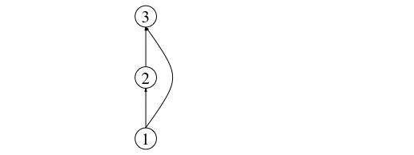

This network can be represented as an adjacency matrix thus:

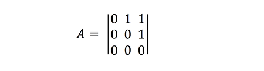

More sophisticated ways of representing and storing networks exist, such as for example the [GraphML](http://graphml.graphdrawing.org) format, in which additional information about the network, the nodes, and the links can be included in the description. During these lectures, we will use a mixture of different formats to represent networks in text files (e.g. edge lists, adjacency matrices, etc).

Throughout the course we will use a few examples of real ecological networks taken publicly available databases such as the well-known food web from the Benguela upwelling marine system off the Western coast of Africa:

[figure not shown]

Image taken from Yodzis, P (1998) *Local trophodynamics and the interaction of marine mammals and fisheries in the Benguela ecosystem*. **Journal of Animal Ecology**. 67, 635-658.

This, and other ecological networks datasets, are available from the [Global Food Web Database](https://www.canberra.edu.au/globalwebdb/).

The code below will enable you to download the edgelist file and use it to create an adjacency matrix representation of the network. Two representations of the network then remain available: the Edgelist representation (`benguela.EL`) and the Adjacency Matrix representation (`benguela.AM`).

```r
library(RCurl)
x <- getURL("https://raw.githubusercontent.com/mlurgi/networks_for_r/master/datasets/benguela.edgelist")
benguela.EL <- read.table(text = x)
benguela.EL <- as.matrix(benguela.EL)
benguela.EL <- benguela.EL + 1  # Because the species indices start from 0 on the file
```

```r
# Create an adjacency matrix called benguela.AM, containing only zeros
benguela.AM <- matrix(0, max(benguela.EL), max(benguela.EL))

# Introduce ones to the matrix to represent interactions between species
benguela.AM[benguela.EL] <- 1
```

## 1.3 Species and interactions as vertices and links

In abstract representations of ecological communities as networks, nodes represent species and links amongst them denote ecological interactions happening between the represented species.

**Adjacency matrices** are matrix representations of networks where elements of the matrix denote the presence of a link (i.e. interaction) between the species represented by the row and the species represented by the column. Thus, to represent a food web composed of S species as a matrix we need a SxS matrix in order to be able to represent all possible interaction between the S species. The number of species in the network can be calculated thus as the number of rows or the number of columns.

Using the Benguela food web adjacency matrix `benguela.AM`, you can calculate the number of species.

In an adjacency matrix, all species are represented by columns and rows. Counting the number of columns or rows in the adjacency matrix will let you obtain the number of species in the food web. In R, you can use the `dim` function to look at the matrix **dimensions**.

```r
# species richness
S <- dim(benguela.AM)[1]
```

Similarly, since interactions are represented as ones in the matrix, if you `sum` all the values in the matrix, you will get the number of interactions.

```r
# number of links
L <- sum(benguela.AM)
```

## 1.4 Interactions in bipartite networks

Food webs, like that for the Benguela ecosystem studied above, are network representation of who eats whom relationships in an ecological community. As such, there are no distinct subset of species among which interactions are not possible. This is why adjacency matrices for representing food webs contain the total number of species as rows and also as columns. In theory, any interaction is possible.

Other types of ecological networks, however, like for example, plant-animal mutualistic networks (like the figure below) or host-parasite interaction networks, exhibit a bipartite structure. In this type of networks, species can be classified into two distinct groups where interactions do not occur (or are forbidden) among members of the same group. For example, in a plant-animal mutualistic network, plants do not interact with plants and animal mutualists do not interact among them. This feature allows for a more concise matrix representation of bipartite networks.

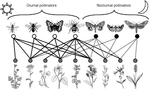

**Example of a plant-animal pollinator bipartite network.** Image taken from MacGregor, CJ et al. (2015) *Pollination by nocturnal Lepidoptera, and the effects of light pollution, a review*. **Ecological Entomology**. 40, 187-198.

As we saw above, the equivalent representation of an adjacency matrix for a bipartite network is called an incidence matrix. In incidence matrices one set of species are represented as rows (e.g. hosts/plants), and the other set of species as columns (e.g. visitors/mutualists). Thus, the way of counting species in an incidence matrix representing a mutualistic (bipartite) network is different from that used to count species in adjacency matrices representing food webs.

For a bipartite ecological network represented by an incidence matrix with size HxV, where H is the number of rows and V is the number of columns, the number of species in the network is equal to H + V.

As an example, we load a matrix representing a bipartite network of interactions between anemones and several species of fish living within them in South-East Asia. This network was taken from Ollerton, J. et al. (2007) *Finding NEMO: nestedness engendered by mutualistic organization in anemonefish and their hosts*. **Proceedings of the Royal Society B**. 274, 591-598.

Try and calculate the total number of anemone *and* fish species in the network. Remember that in a bipartite network, one set of species (in this case, anemones) are represented as columns, while the other set (in this case, fishes) are represented as rows.

```r
y <- getURL("https://raw.githubusercontent.com/mlurgi/networks_for_r/master/datasets/anemonefish.txt")
anemonef <- read.table(text = y)
names(anemonef) <- paste("A", 1:10, sep = "")
row.names(anemonef) <- paste("F", 1:26, sep = "")
anemonef <- as.matrix(anemonef)

### The number of fish species in the network is the number of rows
n_fish <- dim(anemonef)[1]
### The number of anemone species is the number of columns
n_anemone <- dim(anemonef)[2]

### So, the total number of species is the sum of these two quantities
S <- n_fish + n_anemone

### Whereas the total number of interactions is still the sum of the matrix
L <- sum(anemonef)
```

## 1.5 Networks as graphs

As we have seen, edge lists and adjacency matrices are convenient ways in which interaction networks can be represented. However, more flexible formats for representing networks are needed when we want to perform more complex actions on networks, or even just for visualisation purposes.

Several computer programming libraries have been especially developed to construct and manipulate graphs. These libraries make it easy and widely accessible to work with and study networks. Amongst the most popular the [NetworkX](https://networkx.github.io/) complex networks library for [Python](https://www.python.org/) and the [igraph](https://igraph.org/) package for network analysis, which can be used on several platforms, including [R](https://www.r-project.org/). For the rest of this course we will be using `igraph` to create and manipulate ecological networks.

To install and load igraph on your R workspace run the following commands:

```r
## Install igraph
install.packages("igraph")

## Load igraph into workspace
library(igraph)
```

To start getting familiar with igraph we will start by creating some simple networks.